# Moneyball Notebook

Let us see what Paul DePodesta did with all the previous years data: The dataset consists of 420 observations of 17 variables consisting of: Team = Name of team, League = American or National league, Year ( from 1999 to 2012), Games = Number of games played by each team in that year, W = Number of wins, RS = Runs scored, RA = Runs against, OBP = On base percentage, SLG = Slugging percentage, BA = Batting Average, OPS = On base plus slugging, OOBP = Opposition on base percentage, OSLG = Opposition slugging percentage, OOPS = Opposition on base plus slugging, Playoffs = 1 if teams makes playoff and 0 otherwise, RankSeason = Rank in season, RankPlayoffs = Rank in playoffs.

$$\\[0.3in]$$
**Understanding the data**

Let us first read the data:

```r
baseball <- read.csv("baseball.csv")
str(baseball)
```

```
'data.frame':   420 obs. of  17 variables:
 $ Team        : chr  "ARI" "ATL" "BAL" "BOS" ...
 $ League      : chr  "NL" "NL" "AL" "AL" ...
 $ Year        : int  2012 2012 2012 2012 2012 2012 2012 2012 2012 2012 ...
 $ Games       : int  162 162 162 162 162 162 162 162 162 162 ...
 $ W           : int  81 94 93 69 61 85 97 68 64 88 ...
 $ RS          : int  734 700 712 734 613 748 669 667 758 726 ...
 $ RA          : int  688 600 705 806 759 676 588 845 890 670 ...
 $ OBP         : num  0.328 0.32 0.311 0.315 0.302 0.318 0.315 0.324 0.33 0.335 ...
 $ SLG         : num  0.418 0.389 0.417 0.415 0.378 0.422 0.411 0.381 0.436 0.422 ...
 $ BA          : num  0.259 0.247 0.247 0.26 0.24 0.255 0.251 0.251 0.274 0.268 ...
 $ OPS         : num  0.746 0.709 0.728 0.73 0.68 0.74 0.726 0.705 0.766 0.757 ...
 $ OOBP        : num  0.317 0.306 0.315 0.331 0.335 0.319 0.305 0.336 0.357 0.314 ...
 $ OSLG        : num  0.415 0.378 0.403 0.428 0.424 0.405 0.39 0.43 0.47 0.402 ...
 $ OOPS        : num  0.732 0.684 0.718 0.759 0.759 0.724 0.695 0.766 0.827 0.716 ...
 $ Playoffs    : int  0 1 1 0 0 0 1 0 0 1 ...
 $ RankSeason  : int  NA 4 5 NA NA NA 2 NA NA 6 ...
 $ RankPlayoffs: int  NA 5 4 NA NA NA 4 NA NA 2 ...
```

```r
summary(baseball)
```

```
     Team              League               Year          Games             W                RS               RA              OBP              SLG
 Length:420         Length:420         Min.   :1999   Min.   :161.0   Min.   : 43.00   Min.   : 513.0   Min.   : 529.0   Min.   :0.2920   Min.   :0.3390
 Class :character   Class :character   1st Qu.:2002   1st Qu.:162.0   1st Qu.: 72.00   1st Qu.: 706.0   1st Qu.: 697.0   1st Qu.:0.3220   1st Qu.:0.4017
 Mode  :character   Mode  :character   Median :2006   Median :162.0   Median : 81.00   Median : 752.5   Median : 754.5   Median :0.3320   Median :0.4200
                                       Mean   :2006   Mean   :161.9   Mean   : 80.96   Mean   : 759.5   Mean   : 759.5   Mean   :0.3323   Mean   :0.4197
                                       3rd Qu.:2009   3rd Qu.:162.0   3rd Qu.: 90.00   3rd Qu.: 813.0   3rd Qu.: 823.5   3rd Qu.:0.3410   3rd Qu.:0.4370
                                       Max.   :2012   Max.   :163.0   Max.   :116.00   Max.   :1009.0   Max.   :1028.0   Max.   :0.3730   Max.   :0.4910

       BA              OPS             OOBP             OSLG             OOPS           Playoffs        RankSeason     RankPlayoffs
 Min.   :0.2330   Min.   :0.637   Min.   :0.2940   Min.   :0.3460   Min.   :0.6460   Min.   :0.0000   Min.   :1.000   Min.   :1.000
 1st Qu.:0.2560   1st Qu.:0.725   1st Qu.:0.3210   1st Qu.:0.4010   1st Qu.:0.7228   1st Qu.:0.0000   1st Qu.:2.000   1st Qu.:3.000
 Median :0.2630   Median :0.752   Median :0.3310   Median :0.4190   Median :0.7515   Median :0.0000   Median :4.000   Median :4.000
 Mean   :0.2636   Mean   :0.752   Mean   :0.3323   Mean   :0.4197   Mean   :0.7520   Mean   :0.2714   Mean   :3.649   Mean   :3.158
 3rd Qu.:0.2710   3rd Qu.:0.778   3rd Qu.:0.3430   3rd Qu.:0.4380   3rd Qu.:0.7800   3rd Qu.:1.0000   3rd Qu.:5.000   3rd Qu.:4.000
 Max.   :0.2940   Max.   :0.851   Max.   :0.3840   Max.   :0.4990   Max.   :0.8830   Max.   :1.0000   Max.   :7.000   Max.   :5.000
                                                                                                      NA's   :306     NA's   :306
```

Paul DePodesta reduced the planning problem for the upcoming season to a mathematics problem.

Question that motivated him: What would it take to make the playoffs?

```r
table(baseball$Year)
```

```
1999 2000 2001 2002 2003 2004 2005 2006 2007 2008 2009 2010 2011 2012
  30   30   30   30   30   30   30   30   30   30   30   30   30   30
```

```r
baseball2002 <- subset(baseball, Year < 2002)
str(baseball2002)
```

```
'data.frame':   90 obs. of  17 variables:
 $ Team        : chr  "ANA" "ARI" "ATL" "BAL" ...
 $ League      : chr  "AL" "NL" "NL" "AL" ...
 $ Year        : int  2001 2001 2001 2001 2001 2001 2001 2001 2001 2001 ...
 $ Games       : int  162 162 162 162 161 162 162 162 162 162 ...
 $ W           : int  75 92 88 63 82 88 83 66 91 73 ...
 $ RS          : int  691 818 729 687 772 777 798 735 897 923 ...
 $ RA          : int  730 677 643 829 745 701 795 850 821 906 ...
 $ OBP         : num  0.327 0.341 0.324 0.319 0.334 0.336 0.334 0.324 0.35 0.354 ...
 $ SLG         : num  0.405 0.442 0.412 0.38 0.439 0.43 0.451 0.419 0.458 0.483 ...
 $ BA          : num  0.261 0.267 0.26 0.248 0.266 0.261 0.268 0.262 0.278 0.292 ...
 $ OPS         : num  0.732 0.783 0.736 0.699 0.773 0.766 0.785 0.743 0.808 0.837 ...
 $ OOBP        : num  0.331 0.311 0.314 0.337 0.329 0.321 0.334 0.341 0.341 0.35 ...
 $ OSLG        : num  0.412 0.404 0.384 0.439 0.393 0.398 0.427 0.455 0.417 0.48 ...
 $ OOPS        : num  0.743 0.715 0.698 0.776 0.722 0.719 0.761 0.796 0.758 0.83 ...
 $ Playoffs    : int  0 1 1 0 0 0 0 0 1 0 ...
 $ RankSeason  : int  NA 5 7 NA NA NA NA NA 6 NA ...
 $ RankPlayoffs: int  NA 1 3 NA NA NA NA NA 4 NA ...
```

Let us look at how many games are needed to be won to make playoffs.

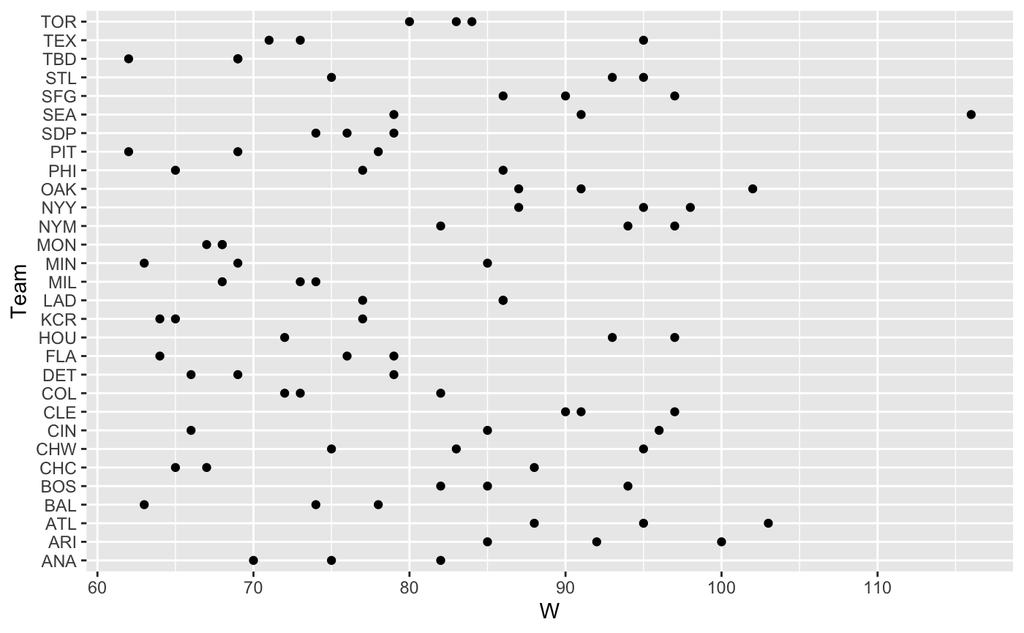

```r
library(ggplot2)
ggplot(baseball2002)+ geom_point(aes(W,Team))
```

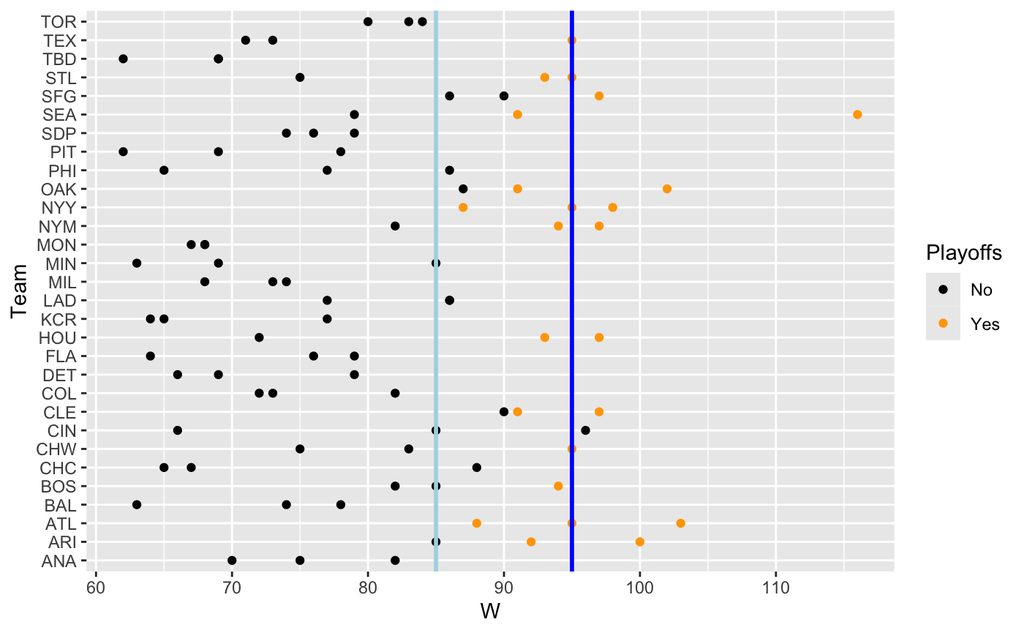

```r
ggplot(baseball2002)+ geom_point(na.rm=T,aes(W,Team,color=as.factor(Playoffs))) +
   scale_color_manual(name="Playoffs",values=c("black","orange"),labels=c("No","Yes")) +  geom_vline(xintercept=95,color="blue",lwd=1) + geom_vline(xintercept=85,color="lightblue",lwd=1)
```

Paul De Podesta judged that it would take around 95 games to make it to playoffs. If they won 95 games and still could not make it to playoffs, then that was just bad luck. So how many runs needed to be scored for and against to win so many games? Bill James, the founder of sabermetrics had earlier noticed that over time, there was a fairly stable relationship between the total runs difference in a season for a team (for-against) and the number of wins.

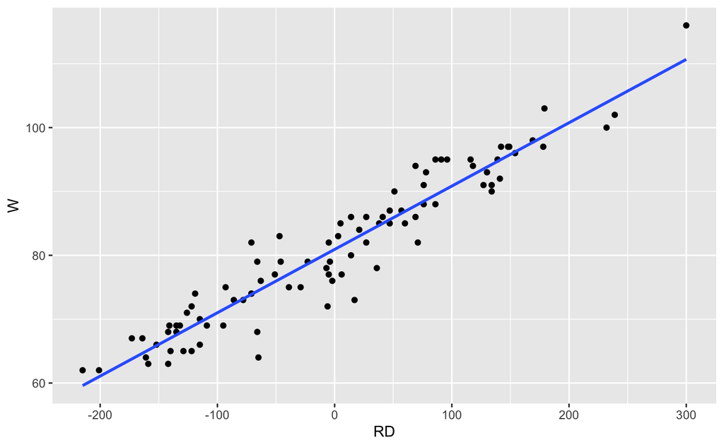

```r
baseball2002$RD <- baseball2002$RS-baseball2002$RA
ggplot(baseball2002,aes(RD,W))+geom_point()+geom_smooth(method="lm",se=F)
```

```r
model1 <- lm(W~RD,data=baseball2002)
summary(model1)
```

```
Call:
lm(formula = W ~ RD, data = baseball2002)

Residuals:
     Min       1Q   Median       3Q      Max
-10.4749  -2.2087   0.3369   2.3860   8.1203

Coefficients:
             Estimate Std. Error t value Pr(>|t|)
(Intercept) 80.922222   0.374248  216.23   <2e-16 ***
RD           0.099190   0.003323   29.85   <2e-16 ***
---
Signif. codes:  0 ‘***’ 0.001 ‘**’ 0.01 ‘*’ 0.05 ‘.’ 0.1 ‘ ’ 1

Residual standard error: 3.55 on 88 degrees of freedom
Multiple R-squared:  0.9101,    Adjusted R-squared:  0.9091
F-statistic:   891 on 1 and 88 DF,  p-value: < 2.2e-16
```

What do you notice about the outputs of anova? (extra) Here,
$$F = \frac{MSR}{MSE}$$
where MSR is the mean square of regression and MSE is the mean square of error. F-statistic: F on y and z DF. y = number of variables, z = nrow - y - 1 reference: https://stats.stackexchange.com/questions/499104/different-output-between-summarylm-and-anovalm-in-r

```r
model1 <- lm(W~RD+OBP,data=baseball2002)
summary(model1)
```

```
Call:
lm(formula = W ~ RD + OBP, data = baseball2002)

Residuals:
     Min       1Q   Median       3Q      Max
-10.2045  -2.2915   0.3557   2.3280   7.8691

Coefficients:
              Estimate Std. Error t value Pr(>|t|)
(Intercept)  88.163011  12.356517   7.135 2.73e-10 ***
RD            0.100882   0.004411  22.872  < 2e-16 ***
OBP         -21.267940  36.277291  -0.586    0.559
---
Signif. codes:  0 ‘***’ 0.001 ‘**’ 0.01 ‘*’ 0.05 ‘.’ 0.1 ‘ ’ 1

Residual standard error: 3.564 on 87 degrees of freedom
Multiple R-squared:  0.9105,    Adjusted R-squared:  0.9084
F-statistic: 442.3 on 2 and 87 DF,  p-value: < 2.2e-16
```

```r
anova(model1)
```

```
Analysis of Variance Table

Response: W
          Df  Sum Sq Mean Sq  F value Pr(>F)
RD         1 11231.2 11231.2 884.3270 <2e-16 ***
OBP        1     4.4     4.4   0.3437 0.5592
Residuals 87  1104.9    12.7
---
Signif. codes:  0 ‘***’ 0.001 ‘**’ 0.01 ‘*’ 0.05 ‘.’ 0.1 ‘ ’ 1
```

```r
model2 <- lm(W~OBP+RD,data=baseball2002)
summary(model2)
```

```
Call:
lm(formula = W ~ OBP + RD, data = baseball2002)

Residuals:
     Min       1Q   Median       3Q      Max
-10.2045  -2.2915   0.3557   2.3280   7.8691

Coefficients:
              Estimate Std. Error t value Pr(>|t|)
(Intercept)  88.163011  12.356517   7.135 2.73e-10 ***
OBP         -21.267940  36.277291  -0.586    0.559
RD            0.100882   0.004411  22.872  < 2e-16 ***
---
Signif. codes:  0 ‘***’ 0.001 ‘**’ 0.01 ‘*’ 0.05 ‘.’ 0.1 ‘ ’ 1

Residual standard error: 3.564 on 87 degrees of freedom
Multiple R-squared:  0.9105,    Adjusted R-squared:  0.9084
F-statistic: 442.3 on 2 and 87 DF,  p-value: < 2.2e-16
```

```r
anova(model2)
```

```
Analysis of Variance Table

Response: W
          Df Sum Sq Mean Sq F value    Pr(>F)
OBP        1 4591.5  4591.5  361.53 < 2.2e-16 ***
RD         1 6644.0  6644.0  523.14 < 2.2e-16 ***
Residuals 87 1104.9    12.7
---
Signif. codes:  0 ‘***’ 0.001 ‘**’ 0.01 ‘*’ 0.05 ‘.’ 0.1 ‘ ’ 1
```

```r
# summary is W~RD+OBP vs W~OBP
# anova W~1 vs W~RD
```

The result indicates a linear fit of the form
$$W = 80.92 + 0.099*RD.$$
To get to playoffs, one need 95 wins (most of the time) and putting in the formula:

```r
RDreqd<-(95-80.92)/0.099
RDreqd
```

```
[1] 142.2222
```

To have 95 wins, you needed around 142 runs difference. In the book, it is stated that Paul Podesta estimated this number to be around 135 (it would depend on the dataset he used),

The summary indicates that slugging percentage and on-base percentage are on similar types of scales.

```r
summary(baseball2002$BA)
```

```
   Min. 1st Qu.  Median    Mean 3rd Qu.    Max.
 0.2460  0.2610  0.2670  0.2684  0.2765  0.2940
```

```r
summary(baseball2002$SLG)
```

```
   Min. 1st Qu.  Median    Mean 3rd Qu.    Max.
 0.3800  0.4153  0.4315  0.4324  0.4507  0.4830
```

```r
summary(baseball2002$OBP)
```

```
   Min. 1st Qu.  Median    Mean 3rd Qu.    Max.
 0.3130  0.3290  0.3410  0.3405  0.3518  0.3730
```

```r
summary(baseball2002$OPS)
```

```
   Min. 1st Qu.  Median    Mean 3rd Qu.    Max.
 0.6990  0.7452  0.7740  0.7728  0.8007  0.8400
```

Linear regression models: Predicting runs scored from OBP, SLG, BA and OPS.

With one dependent variable:

```r
m1 <- lm(RS~OBP,data=baseball2002)
summary(m1)
```

```
Call:
lm(formula = RS ~ OBP, data = baseball2002)

Residuals:
    Min      1Q  Median      3Q     Max
-79.492 -20.333  -0.272  22.810  83.676

Coefficients:
            Estimate Std. Error t value Pr(>|t|)
(Intercept) -1046.80      85.91  -12.19   <2e-16 ***
OBP          5452.59     252.13   21.63   <2e-16 ***
---
Signif. codes:  0 ‘***’ 0.001 ‘**’ 0.01 ‘*’ 0.05 ‘.’ 0.1 ‘ ’ 1

Residual standard error: 32.75 on 88 degrees of freedom
Multiple R-squared:  0.8416,    Adjusted R-squared:  0.8398
F-statistic: 467.7 on 1 and 88 DF,  p-value: < 2.2e-16
```

```r
m2 <- lm(RS~SLG,data=baseball2002)
summary(m2)
```

```
Call:
lm(formula = RS ~ SLG, data = baseball2002)

Residuals:
    Min      1Q  Median      3Q     Max
-93.368 -25.082  -0.904  20.041  99.113

Coefficients:
            Estimate Std. Error t value Pr(>|t|)
(Intercept)  -442.85      74.54  -5.941 5.55e-08 ***
SLG          2896.65     172.12  16.829  < 2e-16 ***
---
Signif. codes:  0 ‘***’ 0.001 ‘**’ 0.01 ‘*’ 0.05 ‘.’ 0.1 ‘ ’ 1

Residual standard error: 40.07 on 88 degrees of freedom
Multiple R-squared:  0.7629,    Adjusted R-squared:  0.7603
F-statistic: 283.2 on 1 and 88 DF,  p-value: < 2.2e-16
```

```r
m3 <- lm(RS~OPS,data=baseball2002)
summary(m3)
```

```
Call:
lm(formula = RS ~ OPS, data = baseball2002)

Residuals:
    Min      1Q  Median      3Q     Max
-73.074 -14.971  -4.293  12.801  69.052

Coefficients:
            Estimate Std. Error t value Pr(>|t|)
(Intercept)  -846.05      60.54  -13.98   <2e-16 ***
OPS          2142.30      78.25   27.38   <2e-16 ***
---
Signif. codes:  0 ‘***’ 0.001 ‘**’ 0.01 ‘*’ 0.05 ‘.’ 0.1 ‘ ’ 1

Residual standard error: 26.68 on 88 degrees of freedom
Multiple R-squared:  0.8949,    Adjusted R-squared:  0.8937
F-statistic: 749.6 on 1 and 88 DF,  p-value: < 2.2e-16
```

```r
m4 <- lm(RS~BA,data=baseball2002)
summary(m4)
```

```
Call:
lm(formula = RS ~ BA, data = baseball2002)

Residuals:
    Min      1Q  Median      3Q     Max
-97.397 -29.208  -3.644  27.924 139.192

Coefficients:
            Estimate Std. Error t value Pr(>|t|)
(Intercept)   -778.9      120.6  -6.457 5.67e-09 ***
BA            5917.7      449.0  13.180  < 2e-16 ***
---
Signif. codes:  0 ‘***’ 0.001 ‘**’ 0.01 ‘*’ 0.05 ‘.’ 0.1 ‘ ’ 1

Residual standard error: 47.72 on 88 degrees of freedom
Multiple R-squared:  0.6638,    Adjusted R-squared:  0.6599
F-statistic: 173.7 on 1 and 88 DF,  p-value: < 2.2e-16
```

$$\\[0.3in]$$
**Model Selection**

Let’s determine which are the important variables to add into our model:

```r
# Here I present two alternatives. I prefer the first one due to its ease of implementation
library(MASS)
mAIC <- lm(RS~OBP+SLG+BA+OPS,data=baseball2002)
stepAIC(mAIC)
```

```
Start:  AIC=569.97
RS ~ OBP + SLG + BA + OPS


Step:  AIC=569.97
RS ~ OBP + SLG + BA

       Df Sum of Sq    RSS    AIC
- BA    1       187  46535 568.33
<none>               46348 569.97
- SLG   1     36180  82528 619.90
- OBP   1     65817 112165 647.51

Step:  AIC=568.33
RS ~ OBP + SLG

       Df Sum of Sq    RSS    AIC
<none>               46535 568.33
- SLG   1     47861  94396 629.99
- OBP   1     94768 141304 666.30

Call:
lm(formula = RS ~ OBP + SLG, data = baseball2002)

Coefficients:
(Intercept)          OBP          SLG
      -1014         3562         1413
```

```r
# Second alternative. Harder to learn but gives more customization, can perform exhaustive search.
library(leaps)
mReg <- regsubsets(RS~OBP+SLG+BA+OPS, data=baseball2002, method = "exhaustive")
mRegdata <- summary(mReg)
```

We see that RS = -1014 + 3562 * OBP + 1413 * SLG

We can view the available data in `mRegdata` by using the down arrow in the global environment. We look for the subset with minimum cp. The cp statistic is closely related to AIC, where minimizing Mallow’s CP is equivalent to minimizing the AIC. We see that the model with 2 variables minimizes the cp, hence the AIC. Regardless, we will test if adding BA improves the model in any regard.

```r
mRegdata
```

```
Subset selection object
Call: regsubsets.formula(RS ~ OBP + SLG + BA + OPS, data = baseball2002,
    method = "exhaustive")
4 Variables  (and intercept)
    Forced in Forced out
OBP     FALSE      FALSE
SLG     FALSE      FALSE
BA      FALSE      FALSE
OPS     FALSE      FALSE
1 subsets of each size up to 3
Selection Algorithm: exhaustive
         OBP SLG BA  OPS
1  ( 1 ) " " " " " " "*"
2  ( 1 ) "*" "*" " " " "
3  ( 1 ) "*" "*" "*" " "
```

```r
mRegdata$cp # visual inspection is sufficient
```

```
[1] 28.858339  1.343442  3.000000
```

```r
mRegdata$adjr2
```

```
[1] 0.8937384 0.9201367 0.9195332
```

```r
# Add `BA`
m5 <- lm(RS~OBP+SLG, data=baseball2002)
m6 <- lm(RS~OBP+SLG+BA, data=baseball2002)

summary(m5)
```

```
Call:
lm(formula = RS ~ OBP + SLG, data = baseball2002)

Residuals:
    Min      1Q  Median      3Q     Max
-55.103 -14.808  -3.214  15.314  59.898

Coefficients:
            Estimate Std. Error t value Pr(>|t|)
(Intercept) -1014.02      60.76 -16.688  < 2e-16 ***
OBP          3562.39     267.63  13.311  < 2e-16 ***
SLG          1412.57     149.33   9.459 5.15e-15 ***
---
Signif. codes:  0 ‘***’ 0.001 ‘**’ 0.01 ‘*’ 0.05 ‘.’ 0.1 ‘ ’ 1

Residual standard error: 23.13 on 87 degrees of freedom
Multiple R-squared:  0.9219,    Adjusted R-squared:  0.9201
F-statistic: 513.7 on 2 and 87 DF,  p-value: < 2.2e-16
```

```r
summary(m6)
```

```
Call:
lm(formula = RS ~ OBP + SLG + BA, data = baseball2002)

Residuals:
    Min      1Q  Median      3Q     Max
-53.180 -14.777  -3.514  16.035  58.865

Coefficients:
            Estimate Std. Error t value Pr(>|t|)
(Intercept) -1026.15      64.37 -15.941  < 2e-16 ***
OBP          3466.89     313.72  11.051  < 2e-16 ***
SLG          1369.05     167.09   8.193 2.15e-12 ***
BA            236.43     401.08   0.589    0.557
---
Signif. codes:  0 ‘***’ 0.001 ‘**’ 0.01 ‘*’ 0.05 ‘.’ 0.1 ‘ ’ 1

Residual standard error: 23.21 on 86 degrees of freedom
Multiple R-squared:  0.9222,    Adjusted R-squared:  0.9195
F-statistic:   340 on 3 and 86 DF,  p-value: < 2.2e-16
```

The results indicate that the estimated beta coefficient for OBP is higher in comparison to SLG sugesting that an extra percentage point on base might be more valuable than an extra percentage point of slugging. Note that both variables are statistically significant. Note that OPS weighs them equally. Paul De Podesta decided that it was about three times as important. We also see that adding the extra BA variable in model m6 kept R squared about the same and slightly decreased adjusted R squared. Furthermore this variable is not statistically significant from the result (multicollinearity is a possible reason). We will hence stick to model m5.

A similar analysis can be done for opposition performance.

```r
#summary(baseball2002)
m5_Opp <- lm(RA~OOBP+OSLG,data=baseball2002)
summary(m5_Opp)
```

```
Call:
lm(formula = RA ~ OOBP + OSLG, data = baseball2002)

Residuals:
    Min      1Q  Median      3Q     Max
-82.397 -15.178  -0.129  17.679  60.955

Coefficients:
            Estimate Std. Error t value Pr(>|t|)
(Intercept)  -837.38      60.26 -13.897  < 2e-16 ***
OOBP         2913.60     291.97   9.979 4.46e-16 ***
OSLG         1514.29     175.43   8.632 2.55e-13 ***
---
Signif. codes:  0 ‘***’ 0.001 ‘**’ 0.01 ‘*’ 0.05 ‘.’ 0.1 ‘ ’ 1

Residual standard error: 25.67 on 87 degrees of freedom
Multiple R-squared:  0.9073,    Adjusted R-squared:  0.9052
F-statistic: 425.8 on 2 and 87 DF,  p-value: < 2.2e-16
```

$$\\[0.3in]$$
**Predictions**

The results support the claim in Moneyball that OBP and OOBP has a significant correlation with RS and RA. At the start of 2002, the team OBP = 0.339 and SLG = 0.43 based on player statistics. You can plug this in to the regression equation for model m5 to predict how many runs will be scored.

```r
TIME_SHIFT <- 500
m5$coefficients
```

```
(Intercept)         OBP         SLG
  -1014.018    3562.394    1412.570
```

```r
summary(baseball2002$OBP)
```

```
   Min. 1st Qu.  Median    Mean 3rd Qu.    Max.
 0.3130  0.3290  0.3410  0.3405  0.3518  0.3730
```

```r
summary(baseball2002$SLG)
```

```
   Min. 1st Qu.  Median    Mean 3rd Qu.    Max.
 0.3800  0.4153  0.4315  0.4324  0.4507  0.4830
```

```r
RS_pred<- m5$coefficients[1]+m5$coefficients[2]*0.339+m5$coefficients[3]*0.43
RS_pred
```

```
(Intercept)
   801.0383
```

In the book Paul De Podesta predicted it to be between 800 and 820.

Similarly using opposition statistics, they estimated OOBP = 0.307 and OSLG = 0.373. Plugging in you can estimate RA and then use the first model to predict the number of wins.

```r
m5_Opp$coefficients
```

```
(Intercept)        OOBP        OSLG
  -837.3779   2913.5995   1514.2860
```

```r
RA_pred<- m5_Opp$coefficients[1]+m5_Opp$coefficients[2]*0.307+m5_Opp$coefficients[3]*0.373
RA_pred
```

```
(Intercept)
   621.9258
```

Now we can predict RD

```r
RD_pred<- RS_pred-RA_pred
RD_pred
```

```
(Intercept)
   179.1125
```

So RD is predicted to be 179. Using our model, then number of wins is given by:

```r
model1$coefficients
```

```
(Intercept)          RD         OBP
 88.1630106   0.1008817 -21.2679400
```

```r
W_pred<-80.92 + 0.099*179
W_pred
```

```
[1] 98.641
```

In the book, Paul De Podesta predicted they would win between 93 and 97 games. We predict 98 games. They actually won 103.

Since the whole formulation is based on the idea that Win(W) depends highly on the difference RS-RA and RS and RA separately are well predicted by the variables OBP,SLG and OOBP,OSLG respectively. In following lines we see how W is predicted when we combine all the four variables OBP,SLG,OOBP,OSLG together. This formulation may be difficult to interpret but for the fun of prediction we do the following :

```r
m8 <- lm(W~OBP+SLG+OOBP+OSLG, data=baseball2002)
summary(m8)
```

```
Call:
lm(formula = W ~ OBP + SLG + OOBP + OSLG, data = baseball2002)

Residuals:
     Min       1Q   Median       3Q      Max
-11.7059  -2.5821   0.1212   2.8141   7.6608

Coefficients:
            Estimate Std. Error t value Pr(>|t|)
(Intercept)    76.11      14.01   5.434 5.16e-07 ***
OBP           353.50      47.41   7.457 6.94e-11 ***
SLG           138.11      26.46   5.220 1.25e-06 ***
OOBP         -321.49      46.43  -6.924 7.83e-10 ***
OSLG         -152.13      27.98  -5.438 5.09e-07 ***
---
Signif. codes:  0 ‘***’ 0.001 ‘**’ 0.01 ‘*’ 0.05 ‘.’ 0.1 ‘ ’ 1

Residual standard error: 4.063 on 85 degrees of freedom
Multiple R-squared:  0.8863,    Adjusted R-squared:  0.881
F-statistic: 165.7 on 4 and 85 DF,  p-value: < 2.2e-16
```

```r
vals <- c(1, 0.339, 0.43, 0.307, 0.373)
W_pred_all <- sum(m8$coefficients * vals)
W_pred_all
```

```
[1] 99.89524
```

$$\\[0.3in]$$
**Optimization**

Suppose you are the General Manager of a baseball team, and you are selecting two players for your team. You have a budget of $1,500,000, and you have the choice between the following players:

Player’s Name OBP SLG Salary($) Eric Chavez 0.338 0.540 1,400,000 Jeremy Giambi 0.391 0.450 1,065,000 Frank Menechino 0.369 0.374 295,000 Greg Myers 0.313 0.447 800,000 Carlos Pena 0.361 0.5 300,000

```r
Mat=matrix(c(0.338,0.391,0.369,0.313,0.361,0.540,0.450,0.374,0.447,0.5),nrow=5)
# Scores given based on ability for run scoring
RSP=Mat %*% m5$coefficients[2:3]
RSP
```

```
         [,1]
[1,] 1966.877
[2,] 2028.553
[3,] 1842.825
[4,] 1746.448
[5,] 1992.309
```

We would select Jeremy Giambi and Carlos Pena, since they give the highest contribution to Runs Scored.

We would not select Eric Chavez, since his salary consumes our entire budget, and although he has the highest SLG, there are players with better OBP.

We would not select Frank Menechino since even though he has a high OBP, his SLG is low.

We would not select Greg Myers since he is dominated by Carlos Pena in OBP and SLG, but has a much higher salary.

$$\\[0.3in]$$

**Additional exercises**

1. Diving deeper into computation of the linear regression line.

We know, from our lecture on linear regression that
$$\hat{\beta}=(X'X)^{-1}X'Y.$$
This can be used to manually find the coefficients of the linear regression line if the dataset is small. In this exercise, we will see how. You are given a dataset in the form (x, y): {(1, 0), (3, 2), (5, 6)}.

1. Write down the matrices for X and Y in the formula above, for two regression lines one for which it passes through the origin, and the other of which it does not.
2. Using the formula given above, compute the coefficients for the two regression lines. You should be familiar enough with matrix operations, but you may not have done matrix inverse in R before. To perform matrix inverse in R, use the solve() function. Alternatively, since `X'X` is a `2X2` matrix, we can solve it analytically, where the inversion of a `2X2` matrix is given by
   $$X^{-1}=\frac{1}{ad-bc}\begin{pmatrix}
   d & -b\\
   -c & a
   \end{pmatrix}.$$
3. Write down the codes used to perform linear regression and check if it corresponds with your solutions to (b).
4. Plot the graphs of the points, as well as both the regression lines.
5. Finally, compute the MSE for each of the regression lines.

Sample solution for question 1. Parts (a) and (b)

```r
# For no intercept
X1 = c(1, 3, 5) # 3X1 matrix
Y1 = c(0, 2, 6) # 3X1 matrix
coeff1 <- solve(t(X1) %*% X1) %*% t(X1) %*% Y1
coeff1
```

```
         [,1]
[1,] 1.028571
```

```r
# Include intercept
X2 = matrix(c(1, 1, 1, 1, 3, 5), ncol = 2) # 3X2 matrix
Y2 = c(0, 2, 6) # 3X1 matrix
coeff2 <- solve(t(X2) %*% X2) %*% t(X2) %*% Y2
coeff2
```

```
          [,1]
[1,] -1.833333
[2,]  1.500000
```

```r
MSE2
```

[output not shown]

2. Prediction of runs scored with the opponent’s batting ability taken into consideration.

Perform the same model selection analysis with RS as the independent variable (lines 107 - 130). For this exercise, include the opponents’ team statistics, i.e. the variables OOBP, OSLG and OOPS using both stepAIC() and regsubsets(). Also, for regsubsets(), select the best model using adjr2 as the selection criteria.

Does the opponent’s team statistics play a role in determining the number of runs scored?

Sample solution for question 2.

```r
stepAIC(mAIC)
```

[output not shown]